# Weather Fronts

A front is the transition zone between two air masses of different densities.

- Density differences are often caused temperature differences.

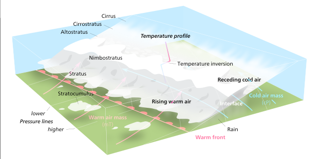

(Image CC: Kelvinsong, CC BY-SA 4.0 https://creativecommons.org/licenses/by-sa/4.0, via Wikimedia Commons)

# Stationary front

- A stationary front is a front with no essential movement
- Surface winds blown parallel to the staionary wind.
- Upper level winds often blown parallel to the stationary front
- If a warm front or cold front stops moving, it becomes a stationary front.
- Once this boundary resumes its forward motion, becomes a warm front or cold front.

# cold front

- when a cold air mass replaces a warm air mass by advancing into it or that the warm air mass retreats and cold air mass advances
- In such a situation, the transition zone between the two is a cold front.
- Cold front moves up to twice as quickly as warm fronts.
- Frontolysis begin when the warm air mass is completely uplifted by the cold air mass

# Warm front

- it is a sloping frontal surface along which active movement of warm air over cold air takes place
- Frontolysis (front dissipation) begin when the warm air mass makes way for cold air mass on the ground,
- when the warm air mass completely sits over the cold air mass.

# Occulded front

- Meteorology a process by which the cold front of a rotating low-pressure system catches up the warm front, so that the warm air between them is forced upwards.
- Such a front is formed when a cold air mass overtakes a warm air mass and goes underneath it.
- Frontolysis begin when warm sector diminishes and the cold air mass completely undertakes the warm sector on ground.
- Thus, a long and backward swinging occluded front is formed which could be a warm front type or cold front type occlusion.